# lab10zad3colab(1)

## Zadanie 3

klasyfikator zdjęć odzieży fashion-MNIST

Wprowadzenie

Zaprojektujemy i wyszkolimy prostą sieć neuronową typu feed-forward, aby sklasyfikować obrazy w 1 z 10 etykiet. Użyjemy keras, biblioteki deep-learning, aby zdefiniować nasz model i go wytrenować.

Zaimportujmy niezbędne biblioteki.

```python
import math
import tensorflow as tf
from tensorflow import keras
import numpy as np
import matplotlib.pyplot as plt
%matplotlib inline
```

Będziemy korzystać z zestawu danych FashionMNIST opublikowanego przez Zalando Research. Ten zbiór danych zawiera obrazy elementów odzieży, takich jak spodnie, płaszcze, torby itp. Zbiór danych składa się z 60 000 obrazów treningowych i 10 000 obrazów testowych. Każdy obraz jest obrazem w skali szarości o rozmiarze 28x28 pikseli. Istnieje łącznie 10 kategorii, a każdej etykiecie jest przypisana liczba od 0 do 9.

Pobieramy i wczytujemy zestaw danych

```python
fashion_mnist = keras.datasets.fashion_mnist
(x_train, y_train), (x_test, y_test) = fashion_mnist.load_data()
x_train.shape, x_test.shape, np.unique(y_train)
```

```
Downloading data from https://storage.googleapis.com/tensorflow/tf-keras-datasets/train-labels-idx1-ubyte.gz
Downloading data from https://storage.googleapis.com/tensorflow/tf-keras-datasets/train-images-idx3-ubyte.gz
Downloading data from https://storage.googleapis.com/tensorflow/tf-keras-datasets/t10k-labels-idx1-ubyte.gz
Downloading data from https://storage.googleapis.com/tensorflow/tf-keras-datasets/t10k-images-idx3-ubyte.gz
```

```
((60000, 28, 28),
 (10000, 28, 28),
 array([0, 1, 2, 3, 4, 5, 6, 7, 8, 9], dtype=uint8))
```

Przypisujemy każdej z etykiet przyjazną dla człowieka nazwę.

```python
class_names = {i:cn for i, cn in enumerate(['T-shirt/top', 'Trouser', 'Pullover', 'Dress', 'Coat',
               'Sandal', 'Shirt', 'Sneaker', 'Bag', 'Ankle boot']) }
```

Narysujmy kilka obrazów i ich etykiety i sprawdźmy nasz zbiór danych.

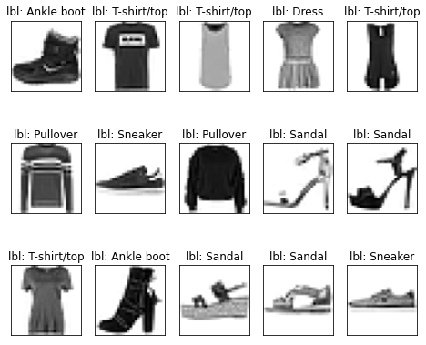

```python
def plot(images, labels, predictions=None):

    # create a grid with 5 columns
    n_cols = min(5, len(images))
    n_rows = math.ceil(len(images) / n_cols)
    fig, axes = plt.subplots(n_rows, n_cols, figsize=(n_cols+3, n_rows+4))

    if predictions is None:
        predictions = [None] * len(labels)

    for i, (x, y_true, y_pred) in enumerate(zip(images, labels, predictions)):
        ax = axes.flat[i]
        ax.imshow(x, cmap=plt.cm.binary)

        ax.set_title(f"lbl: {class_names[y_true]}")

        if y_pred is not None:
            ax.set_xlabel(f"pred: {class_names[y_pred]}")

        ax.set_xticks([])
        ax.set_yticks([])

# plot first few images
plot(x_train[:15], y_train[:15])
```

Zanim zdefiniujemy nasz model, musimy przeskalować wartości pikseli obrazów.Jeśli sprawdzimy minimalne i maksymalne wartości pikseli w naszym zbiorze danych za pomocą x_train.min(), x_train.max(), otrzymamy odpowiednio 0 i 255. Jednak pożądane jest skalowanie tych wartości między 0 a 1.

```python
x_train = x_train / 255.0
x_test = x_test / 255.0
```

Teraz możemy zdefiniować prostą sieć neuronową typu feed forward za pomocą interfejsu API Keras i wytrenować ją.

Najpierw dodajemy warstwę Flatten do naszego modelu, aby przekonwertować dane wejściowe 2D na 1D. Ponieważ sieci neuronowe typu feed forward działają tylko z wejściem 1D, musimy je wcześniej spłaszczyć.

```python
from tensorflow.keras.layers import Flatten, add, Dense, Dropout
from tensorflow.keras.callbacks import EarlyStopping
from tensorflow.keras.models import Sequential

modelP = tf.keras.Sequential()
modelP.add(Flatten(input_shape=(28, 28)))
modelP.add(Dense(128, activation='relu'))
modelP.add(Dropout(0.2))
modelP.add(Dense(64, activation='relu'))
modelP.add(Dropout(0.2))
modelP.add(Dense(32, activation='relu'))
modelP.add(Dropout(0.2))
modelP.add(Dense(10, activation = 'softmax'))

EarlyStop = EarlyStopping(monitor='val_loss', patience=3, verbose=1)

modelP.compile(optimizer="adam", loss="sparse_categorical_crossentropy", metrics=["accuracy"])
modelP.fit(x_train, y_train, batch_size=60, epochs=10, validation_split=0.2, callbacks = [EarlyStop])
```

```
<tensorflow.python.keras.callbacks.History at 0x7f36ba010438>
```

```python
loss, accuracy = modelP.evaluate(x_test, y_test)
print(f"Accuracy = {accuracy*100:.2f} %")
```

```
Accuracy = 86.83 %
```

Na zestawie testowym dokładność wynosi prawie 87%.

Do interaktywnej wizualizacji wyników użyjemy widżetów.

W poniższym przykładzie jako widget wejściowy mamy suwak liczby całkowitej. Za każdym razem, gdy suwak zostanie zmieniony, visualize_prediction wywoływana jest funkcja z wartością suwaka przypisaną do parametru wejściowego i.

```python
from ipywidgets import interact, widgets
img_idx_slider = widgets.IntSlider(value=0, min=0, max=len(x_test)-1, description="Image index")
probs = modelP.predict(x_test)
preds = np.argmax(modelP.predict(x_test), axis=-1)
@interact(i=img_idx_slider)
def visualize_prediction(i=0):
    fix, (ax1, ax2) = plt.subplots(1, 2, figsize=(10, 5))
    ax1.imshow(x_test[i], cmap=plt.cm.binary)
    ax1.set_title(f"lbl: {class_names[y_test[i]]}")
    ax1.set_xlabel(f"pred: {class_names[preds[i]]}")


    ax2.bar(x=[class_names[i] for i in range(10)], height=probs[i]*100)
    plt.xticks(rotation=90)
```

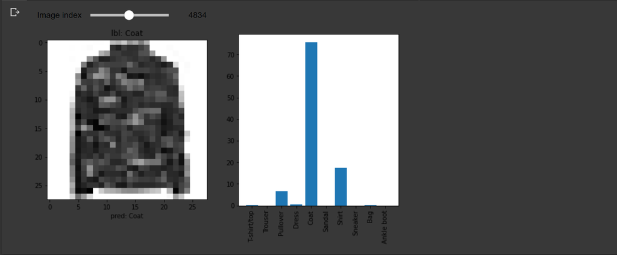